# Exploring the BRFSS data

## Setup

### Load packages

```r
library(ggplot2)
library(dplyr)
library(tidyr)
```

### Load data

```r
load("brfss2013.RData")
```

## Part 1: Data

### Population

Non-institutionalized adult population, aged 18 years or older, who:

- Reside in any of the 50 U.S. states, the District of Columbia, Puerto Rico, and Guam. These areas collect data annually.
- Reside in American Samoa, Federated States of Micronesia, and Palau. These areas collect survey data over a limited point-in-time (usually one to three months).

Note: In this document, the term “state” is used to refer to all areas participating in BRFSS, including the District of Columbia, Guam, and the Commonwealth of Puerto Rico.

### Content

Data on preventive health practices and risk behaviors that are linked to chronic diseases, injuries, and preventable infectious diseases that affect the adult population. Factors assessed by the BRFSS in 2013 include tobacco use, HIV/AIDS knowledge and prevention, exercise, immunization, health status, healthy days — health-related quality of life, health care access, inadequate sleep, hypertension awareness, cholesterol awareness, chronic health conditions, alcohol consumption, fruits and vegetables consumption, arthritis burden, and seatbelt use.

### Collection Method

BRFSS conducts both landline telephone- and cellular telephone-based surveys. In conducting the BRFSS landline telephone survey, interviewers collect data from a randomly selected adult in a household. In conducting the cellular telephone version of the BRFSS questionnaire, interviewers collect data from an adult who participates by using a cellular telephone and resides in a private residence or college housing.

### Analysis

This is an observational study and the telephone-based random sampling used should allow results to be be generalizable to the population discussed above. A few possible reservations:

- Telephone coverage (both landline & cellular) in Puerto Rico, Guam, American Samoa, Micronesia, & Palau may not be as complete as areas within the United States proper.
- Individuals who are without a phone may include sub-groups of interest such as those in poverty.

As an observational study, no treatment was applied and thus random assignment was not used.

## Part 2: Research questions

**Research quesion 1:** Do veterans (veteran3) have more days of poor percieved of mental health over a 30 day period (menthlth)?

**Research quesion 2:** Are Hispanic (X_hispanc) men (sex) getting check-ups at least as frequenly as non-Hispanic men (checkup1)?

**Research quesion 3:** Do women (sex) with only a high school diploma (_educag) have more children in their household (children) than women who graduated from college or technical school?

## Part 3: Exploratory data analysis

**Research quesion 1:** Do veterans (veteran3) have more days of poor percieved of mental health over a 30 day period (menthlth)?

Extract all complete data in the range of the question (0 - 30 days).

```r
vet_mental_health <- brfss2013 %>%
   select(veteran3, menthlth) %>%
   na.omit() %>%
   filter(menthlth >= 0, menthlth <= 30)
```

Generate a summary.

```r
vet_mental_health %>%
   group_by(veteran3) %>%
   summarise(min = min(menthlth)
             , q1 = quantile(menthlth, .25)
             , med = median(menthlth)
             , q3 = quantile(menthlth, .75)
             , max = max(menthlth)
             , avg = mean(menthlth)
             , sd = sd(menthlth)
             )
```

```
## # A tibble: 2 x 8
##   veteran3   min    q1   med    q3   max   avg    sd
##   <fctr>   <dbl> <dbl> <int> <dbl> <dbl> <dbl> <dbl>
## 1 Yes          0     0     0  0     30.0  2.79  7.39
## 2 No           0     0     0  2.00  30.0  3.45  7.74
```

Generate a histogram.

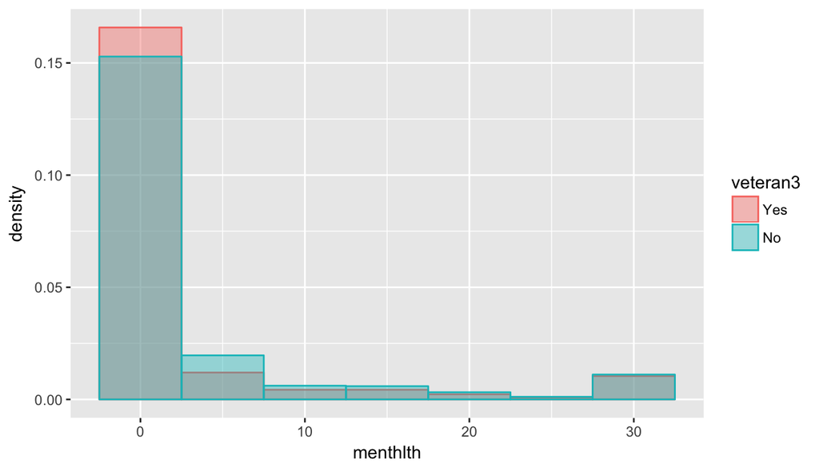

```r
ggplot(vet_mental_health, aes(x=menthlth, fill=veteran3, color=veteran3)) + geom_histogram(binwidth = 5, position = "identity" , alpha=0.4, aes(y=..density..))
```

It appears the sample distribution is not normal, so it’s hard to make a quantitative assesment. However, a qualitative analysis of the histogram appears to indicate that sampled veterans have a lower percentage of days where they percieve their mental health as poor.

**Research quesion 2:** Are Hispanic (X_hispanc) men (sex) getting check-ups at least as frequenly as non-Hispanic men (checkup1)?

Load the relevant data.

```r
hisp_m_phys <- brfss2013 %>%
   select(X_hispanc, sex, checkup1) %>%
   na.omit() %>%
   filter(sex == "Male")
```

Examine relative frequencies between Hispanics & non-Hispanics.

```r
hisp_plot <- hisp_m_phys %>%
   select(X_hispanc, checkup1) %>%
   group_by(X_hispanc, checkup1) %>%
   summarise(n = n()) %>%
   mutate(rel_freq = n / sum(n)) %>%
   mutate(eth = ifelse(X_hispanc == "Hispanic, Latino/a, or Spanish origin", "Hispanic", "non_Hispanic")) %>%
   ungroup() %>%
   select(eth, checkup1, n, rel_freq)

hisp_plot %>%
   select(eth, checkup1, rel_freq) %>%
   spread(eth, rel_freq)
```

```
## # A tibble: 5 x 3
##   checkup1            Hispanic non_Hispanic
## * <fctr>                 <dbl>        <dbl>
## 1 Within past year      0.607       0.692
## 2 Within past 2 years   0.144       0.124
## 3 Within past 5 years   0.107       0.0820
## 4 5 or more years ago   0.103       0.0923
## 5 Never                 0.0390      0.00941
```

Plot the data.

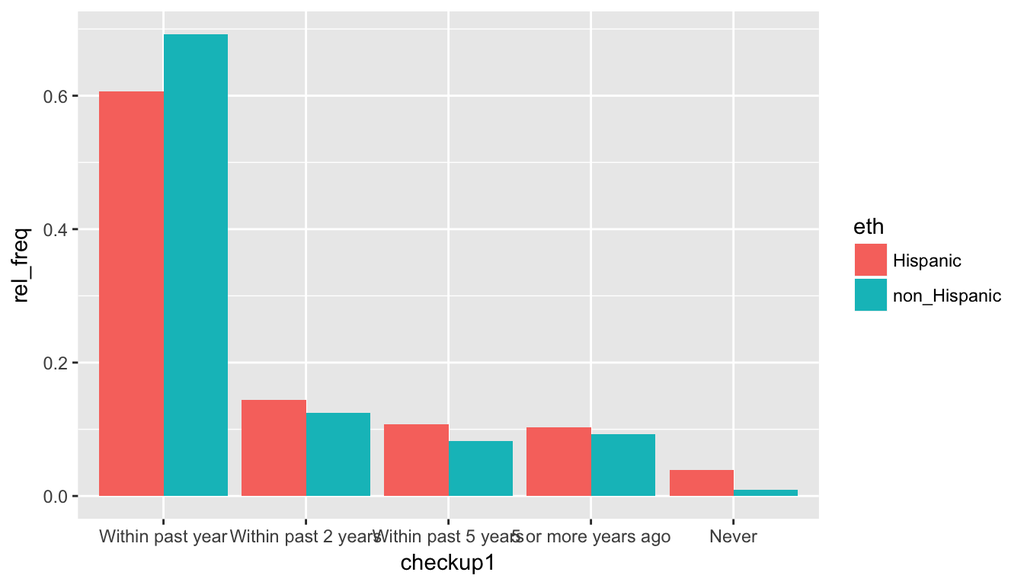

```r
ggplot(hisp_plot, aes(x=checkup1, y=rel_freq, fill=eth)) + geom_bar(stat="identity", position="dodge")
```

While the largest percentage of both Hispanic & non-Hispanics are likely to have yearly check-ups, Hispanics are less likely overall to recieve yearly check-ups vs non-Hispanics. Hispanics are also more likely to go great than 5 years with out a check-up or have never had one.

**Research quesion 3:** Do women (sex) with only a high school diploma (_educag) have more children in their household (children) than women who graduated from college or technical school?

Let’s crunch the numbers.

```r
f_edu_child <- brfss2013 %>%
   select(sex, X_educag, children) %>%
   na.omit() %>%
   filter(sex == "Female", X_educag %in% c("Graduated high school","Graduated from college or technical school")) %>%
   group_by_all() %>%
   summarise(households=n()) %>%
   mutate(degree = ifelse(X_educag == "Graduated high school", "high_school", "assocOrBach")) %>%
   mutate(children.total = children * households) %>%
   ungroup() %>%
   select(degree, households, children.total) %>%
   group_by(degree) %>%
   summarise(children_per_household = sum(children.total) / sum(households))

f_edu_child
```

```
## # A tibble: 2 x 2
##   degree      children_per_household
##   <chr>                        <dbl>
## 1 assocOrBach                  0.580
## 2 high_school                  0.428
```

And plot.

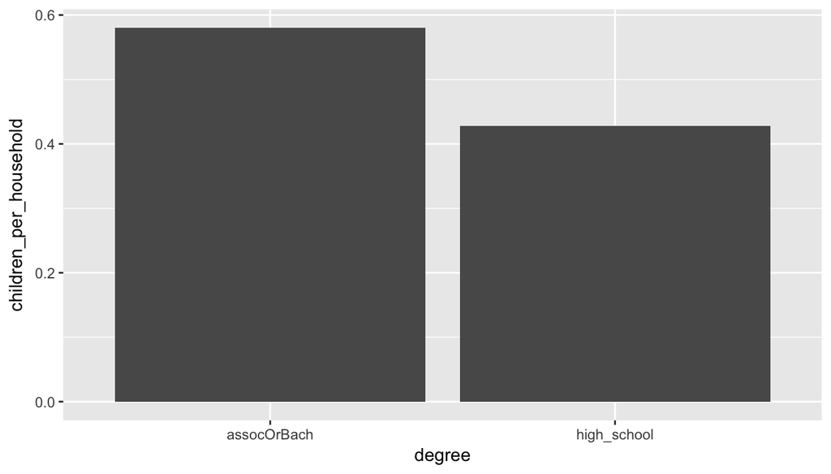

```r
ggplot(f_edu_child, aes(x=degree, y=children_per_household)) + geom_bar(stat="identity", position="dodge")
```

It appears that women with an associates or bachelors degree are parts of households with more children.